# First Pass Markdown

## Eye-tracking only model

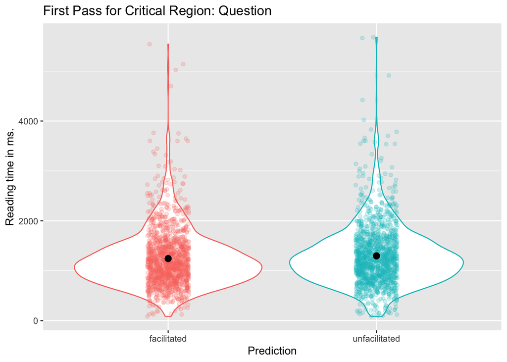

```r
#Let's have a look at region 4

#set condition as a factor
all_data_join$cond <- as.factor(all_data_join$cond)
# Throw away zeroes
all_data_join <- all_data_join %>% filter(R5 != 0)

#Visualisation
all_data_join %>%
  ggplot(aes(x = cond, y = R5, colour = cond)) + ggtitle("First Pass for Critical Region: Question") +
  labs(y = "Reading time in ms.", x = "Prediction") +
  geom_violin() +
  geom_jitter(alpha = .2, width = .1) +
  stat_summary(fun.data = "mean_cl_boot", colour = "black") +
  guides(colour = FALSE)
```

```r
#Descriptives
all_data_join %>%
  group_by(cond) %>%
  summarise(mean(R5), sd(R5))
```

```
## # A tibble: 2 x 3
##   cond          `mean(R5)` `sd(R5)`
##   <fct>              <dbl>    <dbl>
## 1 facilitated        1244.     591.
## 2 unfacilitated      1297.     616.
```

```r
# Model assuming normality of residuals maximal structure
#model.nullR5 <- lmer(R5 ~ (1 | subj) + (1 | item), all_data_join)
modelR5 <- lmer(R5 ~ cond + (1 | subj) + (1 | item), all_data_join)
summary(modelR5)
```

```
## Linear mixed model fit by REML. t-tests use Satterthwaite's method [
## lmerModLmerTest]
## Formula: R5 ~ cond + (1 | subj) + (1 | item)
##    Data: all_data_join
##
## REML criterion at convergence: 40472.2
##
## Scaled residuals:
##     Min      1Q  Median      3Q     Max
## -4.6434 -0.5313 -0.1160  0.3912 10.2140
##
## Random effects:
##  Groups   Name        Variance Std.Dev.
##  subj     (Intercept) 136376   369.3
##  item     (Intercept)  38636   196.6
##  Residual             192206   438.4
## Number of obs: 2675, groups:  subj, 84; item, 32
##
## Fixed effects:
##                   Estimate Std. Error      df t value Pr(>|t|)
## (Intercept)        1243.34      54.54  101.22  22.796  < 2e-16 ***
## condunfacilitated    53.69      16.96 2559.17   3.166  0.00156 **
## ---
## Signif. codes:  0 '***' 0.001 '**' 0.01 '*' 0.05 '.' 0.1 ' ' 1
##
## Correlation of Fixed Effects:
##             (Intr)
## condnfclttd -0.156
```

```r
#anova(modelR5, model.nullR5)

#All the data for this model looks pretty normal.
check_model(modelR5)
```

```
## Not enough model terms in the conditional part of the model to check for multicollinearity.
```

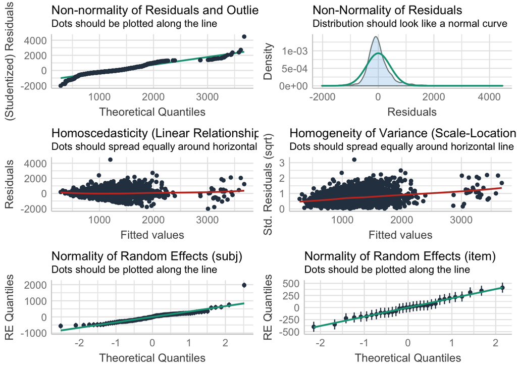

```r
#qqnorm(residuals(modelR5))
#qqline(residuals(modelR5))
#descdist(all_data_join$R5)
```

## Individual differences as controlling factors

```r
#Let's include some co-variates! Region 4

#Step 1: Scale the ID measures...
all_data_join$SRS_total_score_t <- scale(all_data_join$SRS_total_score_t)
all_data_join$EQ <- scale(all_data_join$EQ)
all_data_join$Total_reading_cluster <- scale(all_data_join$Total_reading_cluster)
all_data_join$Total_RAN <- scale(all_data_join$Total_RAN)
all_data_join$"WI _RPI" <- scale(all_data_join$"WI _RPI")
```

```r
# Model including covariates
model_alldatacov_R5 <- lmer(R5 ~ SRS_total_score_t + EQ + Total_reading_cluster + Total_RAN + cond + (1 | subj) +  (1 | item) , data = all_data_join, REML = TRUE)

#model_alldatacov_R5_null <- lmer(R5 ~ SRS_total_score_t + EQ + Total_reading_cluster + #Total_RAN +
#                               (1 + cond | subj) +  (1 + cond | item) , data = #all_data_join, REML = TRUE)

summary(model_alldatacov_R5)
```

```
## Linear mixed model fit by REML. t-tests use Satterthwaite's method [
## lmerModLmerTest]
## Formula: R5 ~ SRS_total_score_t + EQ + Total_reading_cluster + Total_RAN +
##     cond + (1 | subj) + (1 | item)
##    Data: all_data_join
##
## REML criterion at convergence: 39943.3
##
## Scaled residuals:
##     Min      1Q  Median      3Q     Max
## -4.6706 -0.5354 -0.1106  0.3931 10.2142
##
## Random effects:
##  Groups   Name        Variance Std.Dev.
##  subj     (Intercept) 132952   364.6
##  item     (Intercept)  38641   196.6
##  Residual             192077   438.3
## Number of obs: 2643, groups:  subj, 83; item, 32
##
## Fixed effects:
##                       Estimate Std. Error      df t value Pr(>|t|)
## (Intercept)            1245.47      54.36   98.30  22.911  < 2e-16 ***
## SRS_total_score_t       -39.97      52.29   77.99  -0.764  0.44697
## EQ                      -29.11      52.41   77.96  -0.556  0.58013
## Total_reading_cluster   -13.77      42.35   77.98  -0.325  0.74586
## Total_RAN               101.39      42.51   77.99   2.385  0.01950 *
## condunfacilitated        50.78      17.05 2528.05   2.978  0.00293 **
## ---
## Signif. codes:  0 '***' 0.001 '**' 0.01 '*' 0.05 '.' 0.1 ' ' 1
##
## Correlation of Fixed Effects:
##             (Intr) SRS___ EQ     Ttl_r_ Tt_RAN
## SRS_ttl_sc_ -0.001
## EQ           0.004  0.627
## Ttl_rdng_cl -0.007  0.008 -0.007
## Total_RAN   -0.002 -0.058 -0.056  0.263
## condnfclttd -0.157  0.000  0.000  0.000  0.000
```

So Total_RAN and our condition are significant.

If we drop the Total_RAN the effect of condition is still there (see below) - suggesting to me that the effect of Total_RAN is separate from the effect of condition.

```r
model_alldatacov_R5_noRAN <- lmer(R5 ~ SRS_total_score_t + EQ + Total_reading_cluster + cond + (1 | subj) +  (1 | item) , data = all_data_join, REML = TRUE)
summary(model_alldatacov_R5_noRAN)
```

```
## Linear mixed model fit by REML. t-tests use Satterthwaite's method [
## lmerModLmerTest]
## Formula: R5 ~ SRS_total_score_t + EQ + Total_reading_cluster + cond +
##     (1 | subj) + (1 | item)
##    Data: all_data_join
##
## REML criterion at convergence: 40442.6
##
## Scaled residuals:
##     Min      1Q  Median      3Q     Max
## -4.6459 -0.5329 -0.1159  0.3966 10.2124
##
## Random effects:
##  Groups   Name        Variance Std.Dev.
##  subj     (Intercept) 139432   373.4
##  item     (Intercept)  38635   196.6
##  Residual             192206   438.4
## Number of obs: 2675, groups:  subj, 84; item, 32
##
## Fixed effects:
##                       Estimate Std. Error      df t value Pr(>|t|)
## (Intercept)            1243.33      54.87  100.43  22.658  < 2e-16 ***
## SRS_total_score_t       -32.65      53.40   79.99  -0.611  0.54272
## EQ                      -22.50      53.50   79.96  -0.421  0.67520
## Total_reading_cluster   -39.65      41.64   79.98  -0.952  0.34389
## condunfacilitated        53.69      16.96 2559.17   3.166  0.00156 **
## ---
## Signif. codes:  0 '***' 0.001 '**' 0.01 '*' 0.05 '.' 0.1 ' ' 1
##
## Correlation of Fixed Effects:
##             (Intr) SRS___ EQ     Ttl_r_
## SRS_ttl_sc_  0.000
## EQ           0.001  0.627
## Ttl_rdng_cl  0.000  0.023  0.011
## condnfclttd -0.155  0.000  0.000  0.000
```

Does Total_RAN interact with our condition? No (see below.)

```r
model_alldatacov_R5_RAN_int <- lmer(R5 ~ SRS_total_score_t + EQ + Total_reading_cluster + Total_RAN + cond + cond:Total_RAN + (1 | subj) +  (1 | item) , data = all_data_join, REML = TRUE)
summary(model_alldatacov_R5_RAN_int)
```

```
## Linear mixed model fit by REML. t-tests use Satterthwaite's method [
## lmerModLmerTest]
## Formula: R5 ~ SRS_total_score_t + EQ + Total_reading_cluster + Total_RAN +
##     cond + cond:Total_RAN + (1 | subj) + (1 | item)
##    Data: all_data_join
##
## REML criterion at convergence: 39935.7
##
## Scaled residuals:
##     Min      1Q  Median      3Q     Max
## -4.6633 -0.5363 -0.1095  0.3935 10.2123
##
## Random effects:
##  Groups   Name        Variance Std.Dev.
##  subj     (Intercept) 132949   364.6
##  item     (Intercept)  38636   196.6
##  Residual             192152   438.4
## Number of obs: 2643, groups:  subj, 83; item, 32
##
## Fixed effects:
##                             Estimate Std. Error       df t value Pr(>|t|)
## (Intercept)                 1245.471     54.360   98.304  22.912  < 2e-16 ***
## SRS_total_score_t            -39.967     52.291   77.993  -0.764  0.44699
## EQ                           -29.114     52.408   77.962  -0.556  0.58013
## Total_reading_cluster        -13.775     42.349   77.981  -0.325  0.74584
## Total_RAN                    100.355     43.365   84.458   2.314  0.02308 *
## condunfacilitated             50.777     17.055 2527.055   2.977  0.00294 **
## Total_RAN:condunfacilitated    2.061     17.089 2528.137   0.121  0.90403
## ---
## Signif. codes:  0 '***' 0.001 '**' 0.01 '*' 0.05 '.' 0.1 ' ' 1
##
## Correlation of Fixed Effects:
##             (Intr) SRS___ EQ     Ttl_r_ Tt_RAN cndnfc
## SRS_ttl_sc_ -0.001
## EQ           0.004  0.627
## Ttl_rdng_cl -0.007  0.008 -0.007
## Total_RAN   -0.002 -0.057 -0.055  0.258
## condnfclttd -0.157  0.000  0.000  0.000  0.000
## Ttl_RAN:cnd  0.000  0.000  0.000  0.000 -0.198  0.001
```

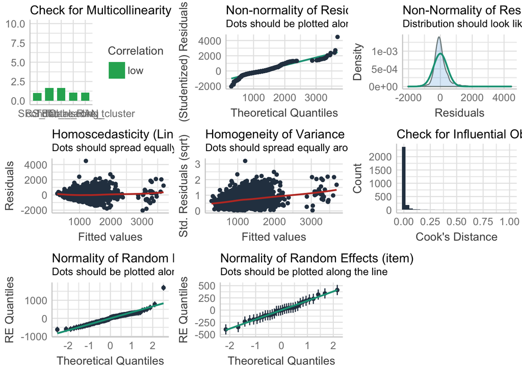

```r
#anova(model_alldatacov_R5_null, model_alldatacov_R5)
check_model(model_alldatacov_R5)
```

```r
ranef(model_alldatacov_R5)
```

```
## $subj
##    (Intercept)
## 1    -62.02784
## 10  -345.20276
## 11    83.12517
## 12   100.86458
## 13  -212.28021
## 14  -124.44843
## 15  -151.66215
## 16   108.22168
## 17   334.07652
## 18   176.86853
## 19    81.37331
## 2    154.74568
## 20   284.60551
```

[output cut: 107 more lines]

Regardless of whether the individual predictors are present/absent, the effect of our condition is pretty much the same - suggesting the variance explained by our experimental manipulation doesn’t overlap with the variance explained by our individual difference measures.